# GIT-JSH-COV-ED-740

Covid Related Excess Deaths

Jehu Humphries

# PACKAGES

- Library for Tweet/User Data Analysis

```r
library(corpus)
library(lubridate)
library(rtweet)
library(SnowballC)
library(tidytext)
library(tidyverse)
library(tm)
```

```r
library(visdat)
library(wordcloud)
```

# Warnings

- Strip Warnings from Outputs

# REDACTED USER CODE

- CODE LINES 16-72 REDACTED FOR USER ##########################
- USER CODE STARTS AT LINE 90 BELOW ########################## # AUTHENTICATION
- Set Authorizations

```r
# appname <- "???"
# key <- "???"
# secret <- "???"
# access_token <- "???"
# access_secret <- "???"
```

# CHANNEL

- Open rTweet channel to Twitter

```r
# my_auth <- rtweet::create_token(
#   app = appname,
#   consumer_key = key,
#   consumer_secret = secret,
#   access_token = access_token,
#   access_secret = access_secret)
```

# COERCE

- Coerce Authentication

```r
# my_auth <- rtweet::create_token()
```

# PULL

- Search RTweets for “excess_deaths” data: 5000 observations / 43 variables
- Pull Users of “excess_deaths” data

```r
# ExcessD_tweets <- search_tweets(q = "excess_deaths",
#                               n = 5000, include_rts = FALSE)
# ExcessD_tweets1 <- users_data(ExcessD_tweets)
```

# DATAFRAME

- Create ExDT DataFrame to combine Tweets and Users data with Selected Columns Only

```r
# ExDTA <- ExcessD_tweets[, c(1,4,6,9,14,20,21,25)]
# ExDTB <- ExcessD_tweets1[, c(3,4,5,6,9,10,11,12,13,15)]
# ExDT <- cbind.data.frame(ExDTA, ExDTB)
```

# COLUMN NAMES

- Change Column Names of DataFrame

```r
# colnames(ExDT)[1] = "Date"
# colnames(ExDT)[2] = "FText"
# colnames(ExDT)[3] = "Range"
# colnames(ExDT)[4] = "Source"
# colnames(ExDT)[5] = "IRName"
# colnames(ExDT)[6] = "RTSCount"
# colnames(ExDT)[7] = "FAVCount"
# colnames(ExDT)[8] = "LANG"
# colnames(ExDT)[9] = "Name"
# colnames(ExDT)[10] = "ScreenN"
# colnames(ExDT)[11] = "LOC"
# colnames(ExDT)[12] = "Descrip"
# colnames(ExDT)[13] = "FollowC"
# colnames(ExDT)[14] = "FriendC"
# colnames(ExDT)[15] = "ListC"
# colnames(ExDT)[16] = "CreatedD"
# colnames(ExDT)[17] = "FavC"
# colnames(ExDT)[18] = "StatusC"
```

# CSV

- Write CSV of dataframe

```r
# write_csv(ExDT, "ExDT10.csv")
```

# USER DATAFRAME

- Start NORMAL unredacted Code. Create DataFrame from .CSV
- 4996 obs. of 18 variables: Atomic Vectors changed to Class=FACTOR

```r
ExDT1 <- read.csv("ExDT10.csv", stringsAsFactors = TRUE)
```

# MUNGE 1

- Verify class as data.frame

```r
ExDT1 <- as.data.frame(ExDT1)
class(ExDT1)
```

```
## [1] "data.frame"
```

# MUNGE 2

- View Variable Classes

```r
str(ExDT1)
```

```
## 'data.frame':    4996 obs. of  18 variables:
##  $ Date    : Factor w/ 4962 levels "2022-11-11T12:13:33Z",..: 4863 4865 4864 4962 4961 4960 4959 4958 4957 4956 ...
##  $ FText   : Factor w/ 4987 levels "'All spring, summer, autumn, winter, we've had excess deaths in the UK, and the rest of the developing world we"| __truncated__,..: 4050 1 3926 4759 326 2676 610 1523 1794 80 ...
##  $ Range   : int  228 196 300 236 88 228 211 287 124 153 ...
##  $ Source  : Factor w/ 31 levels "<a href=\"http://itunes.apple.com/us/app/twitter/id409789998?mt=12\" rel=\"nofollow\">Twitter for Mac</a>",..: 15 25 6 6 21 21 5 6 6 21 ...
##  $ IRName  : Factor w/ 2477 levels "__Kimberly1",..: NA NA NA 1988 173 1672 392 890 1090 12 ...
##  $ RTSCount: int  755 120 108 0 0 0 0 0 0 0 ...
##  $ FAVCount: int  2452 299 357 0 0 0 0 0 0 0 ...
##  $ LANG    : Factor w/ 21 levels "ar","ca","cs",..: 7 7 7 7 7 7 7 7 7 7 ...
##  $ Name    : Factor w/ 3334 levels "'Master Of Crows' 🇺🇲",..: 2994 1066 3094 2653 3288 3244 412 134 3167 900 ...
##  $ ScreenN : Factor w/ 3383 levels "__philipn__",..: 3095 1133 3045 2686 2740 649 441 131 1275 948 ...
##  $ LOC     : Factor w/ 1236 levels "","'B'ham & Black Country' Region",..: 571 1 365 1 965 1057 1 577 1 609 ...
##  $ Descrip : Factor w/ 2634 levels "","'Any fool can deceive the unwary with base flasehood? Whereas, the CHAMPION LIAR scrupulously adheres to incont"| __truncated__,..: 916 2347 1147 2331 2385 2333 1 1841 1424 828 ...
##  $ FollowC : int  231616 467308 313207 14 912 154 86 415 200 1834 ...
##  $ FriendC : int  1158 39 624 19 2188 128 185 401 549 2297 ...
##  $ ListC   : int  2204 1462 916 0 2 6 3 2 0 10 ...
##  $ CreatedD: Factor w/ 3383 levels "Fri Apr 01 07:11:12 +0000 2016",..: 159 2986 2493 2332 1105 863 2161 2088 129 3377 ...
##  $ FavC    : int  7507 10 11090 554 32863 2583 3031 1357 16586 86466 ...
##  $ StatusC : int  7805 74768 30241 647 55024 2704 16765 1270 3422 15880 ...
```

# MUNGE 3

- Change Interger class to Numeric. Change Factor class to Character.

```r
ExDT1$Date <- as.Date(ExDT1$Date)
ExDT1$FText <- as.character(ExDT1$FText)
ExDT1$Range <- as.numeric(ExDT1$Range)
ExDT1$Source <- as.character(ExDT1$Source)
ExDT1$IRName <- as.character(ExDT1$IRName)
ExDT1$RTSCount <- as.numeric(ExDT1$RTSCount)
ExDT1$FAVCount <- as.numeric(ExDT1$FAVCount)
ExDT1$LANG <- as.character(ExDT1$LANG)
ExDT1$Name <- as.character(ExDT1$Name)
ExDT1$ScreenN <- as.character(ExDT1$ScreenN)
ExDT1$LOC <- as.character(ExDT1$LOC)
ExDT1$Descrip <- as.character(ExDT1$Descrip)
ExDT1$FollowC <- as.numeric(ExDT1$FollowC)
ExDT1$FriendC <- as.numeric(ExDT1$FriendC)
ExDT1$ListC <- as.numeric(ExDT1$ListC)
ExDT1$CreatedD <- as.character(ExDT1$CreatedD)
ExDT1$FavC <- as.numeric(ExDT1$FavC)
ExDT1$StatusC <- as.numeric(ExDT1$StatusC)
```

# MUNGE 4

- Change Date Variable for (NOV22) to Day Only and Change Class to Numeric

```r
ExDT1$Date <- format(as.Date(ExDT1$Date, format="%Y/%m/%d"),"%d")
ExDT1$Date <- as.numeric(ExDT1$Date)
```

# MUNGE 5

- View Variable Class changes

```r
str(ExDT1)
```

```
## 'data.frame':    4996 obs. of  18 variables:
##  $ Date    : num  16 16 16 18 18 18 18 18 18 18 ...
##  $ FText   : chr  "Dame Jenny Harries is blaming the summer heatwaves for nearly 3,000 excess deaths, pinning them on climate chan"| __truncated__ "'All spring, summer, autumn, winter, we've had excess deaths in the UK, and the rest of the developing world we"| __truncated__ "Another lie courtesy…
##  $ Range   : num  228 196 300 236 88 228 211 287 124 153 ...
##  $ Source  : chr  "<a href=\"https://buffer.com\" rel=\"nofollow\">Buffer</a>" "<a href=\"https://studio.twitter.com\" rel=\"nofollow\">Twitter Media Studio</a>" "<a href=\"http://twitter.com/download/iphone\" rel=\"nofollow\">Twitter for iPhone</a>" "<a href=\"http://twitter.com/download/iphone\…
##  $ IRName  : chr  NA NA NA "S3venSix" ...
##  $ RTSCount: num  755 120 108 0 0 0 0 0 0 0 ...
##  $ FAVCount: num  2452 299 357 0 0 ...
##  $ LANG    : chr  "en" "en" "en" "en" ...
##  $ Name    : chr  "Toby Young" "GB News" "Viva Frei" "Seven Six 🇨🇦" ...
##  $ ScreenN : chr  "toadmeister" "GBNEWS" "thevivafrei" "S3venSix" ...
##  $ LOC     : chr  "London" "" "Florida, USA" "" ...
##  $ Descrip : chr  "General Secretary of Free Speech Union (https://t.co/eawHb6Hmso) Editor-in-Chief of Daily Sceptic (https://t.co"| __truncated__ "Virgin Media HD 604, Freesat 216, Sky 515, Freeview 236, YouView 236, DAB+ Radio, YouTube, mobile, online & DAB"| __truncated__ "I don’t consider mys…
##  $ FollowC : num  231616 467308 313207 14 912 ...
##  $ FriendC : num  1158 39 624 19 2188 ...
##  $ ListC   : num  2204 1462 916 0 2 ...
##  $ CreatedD: chr  "Fri Jan 09 18:31:18 +0000 2009" "Wed Dec 16 11:11:23 +0000 2020" "Tue Dec 15 03:46:15 +0000 2009" "Thu Oct 28 01:31:16 +0000 2021" ...
##  $ FavC    : num  7507 10 11090 554 32863 ...
##  $ StatusC : num  7805 74768 30241 647 55024 ...
```

# MUNGE 6

- Observe Statistical Min/Mean/Max of Numeric Variables

```r
summary(ExDT1)
```

```
##       Date          FText               Range          Source
##  Min.   :11.00   Length:4996        Min.   : 13.0   Length:4996
##  1st Qu.:12.00   Class :character   1st Qu.:142.0   Class :character
##  Median :13.00   Mode  :character   Median :225.0   Mode  :character
##  Mean   :13.38                      Mean   :220.2
##  3rd Qu.:15.00                      3rd Qu.:283.0
##  Max.   :18.00                      Max.   :965.0
##     IRName             RTSCount          FAVCount            LANG
##  Length:4996        Min.   :   0.00   Min.   :   0.000   Length:4996
##  Class :character   1st Qu.:   0.00   1st Qu.:   0.000   Class :character
##  Mode  :character   Median :   0.00   Median :   0.000   Mode  :character
##                     Mean   :   3.33   Mean   :   8.385
##                     3rd Qu.:   0.00   3rd Qu.:   2.000
##                     Max.   :2301.00   Max.   :3951.000
##      Name             ScreenN              LOC              Descrip
##  Length:4996        Length:4996        Length:4996        Length:4996
##  Class :character   Class :character   Class :character   Class :character
##  Mode  :character   Mode  :character   Mode  :character   Mode  :character
##
##
##
##     FollowC           FriendC          ListC           CreatedD
##  Min.   :      0   Min.   :    0   Min.   :   0.00   Length:4996
##  1st Qu.:     71   1st Qu.:  148   1st Qu.:   0.00   Class :character
##  Median :    304   Median :  466   Median :   2.00   Mode  :character
##  Mean   :   4361   Mean   : 1191   Mean   :  33.56
##  3rd Qu.:   1036   3rd Qu.: 1275   3rd Qu.:   7.00
##  Max.   :4201080   Max.   :48544   Max.   :6818.00
##       FavC           StatusC
##  Min.   :     0   Min.   :     1
##  1st Qu.:  1635   1st Qu.:  2199
##  Median :  7038   Median :  7048
##  Mean   : 26903   Mean   : 21778
##  3rd Qu.: 25591   3rd Qu.: 20882
##  Max.   :771914   Max.   :797542
```

# MUNGE 7

- Observe Head Data

```r
head(ExDT1)
```

```
##   Date
## 1   16
## 2   16
## 3   16
## 4   18
## 5   18
## 6   18
##                                                                                                                                                                                                                                                                                                          …
## 1                                                                                                 Dame Jenny Harries is blaming the summer heatwaves for nearly 3,000 excess deaths, pinning them on climate change. But these deaths were part of a trend since April, and the cold kills more than the …
## 2                                                                                                       'All spring, summer, autumn, winter, we've had excess deaths in the UK, and the rest of the developing world were very curious about the cause.'\n\nMark Steyn gives his take on G20, Ulster, and…
## 3 Another lie courtesy of big pharma spokesman @joshzepps. Leading cause of death in Alberta is now “unknown causes” - having surpassed dementia. New Brunswick noting a trend of unexplained excess deaths. Spin, lies, &amp; propaganda. The absolute state of  modern “journalism”. https://t.co/Ti7yG…
## 4                                                                                 The ENDLESS propaganda at CBC is just insane!\n\nStop making up the narratives! Your SUPPOSED to be reporting the NEWS!!\n\nFking clowns\n\nThe daily BS is unbearable.\n\nTry covering how many excess deaths, not cov…
## 5                                                                                                                                                                                                                                             @ARCRooksmoor @BohemianAtmosp1 i gather you have not seen t…
## 6                                                                                                 @NothingWrong48 @Mish_is_waiting @pogorelov_ian @Solidarity_Star @uamemesforces America winning the cold war resulted in 10M+ excess deaths all over Eastern Europe from 1990 to 2005 lmao IDK that you…
##   Range
```

[output cut: 41 more lines]

# MUNGE 8

- Observe Tail Data

```r
tail(ExDT1)
```

```
##      Date
## 4991   11
## 4992   11
## 4993   11
## 4994   11
## 4995   11
## 4996   11
##                                                                                                                                                                                                                                                                                                          …
## 4991                                                                                                                                                                                                                                                                                                     …
## 4992                                                                                                                                                                                                                                                                                                     …
## 4993                                                                                                                                                                                                                                                                                                     …
## 4994                                                                                                                                                                                                                                                                                                     …
## 4995                                                                                                                                                                                                                                                                                                     …
## 4996 @KellyGoodmanPhD @crabb_vicki @JKelleyK @JimeeLiberty @IdunsDaughter @ZeetubesII @WendyOrent @richykirsh @Pouldeau61 @RadioColor @swedishchf @MaureenStroud @Monstercoyliar @AspAlaAsnAsnTyr @mcfunny @pawley_robert @provaxtexan @doritmi @Jaytee116James @jtmayes3 @nuhope2022 @kevinoler @reachar…
##      Range
```

[output cut: 41 more lines]

# MUNGE 9

- ExDT1 Data is Categorized between Character and Numeric Classes. IRName has ‘NAs’

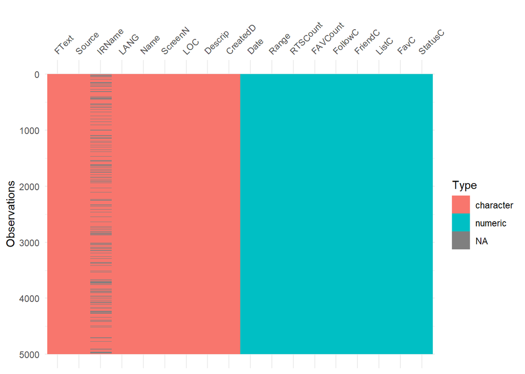

```r
vis_dat(ExDT1, warn_large_data = FALSE)
```

# MUNGE 10 - All Data in ExDT1 == IRName has ‘NAs’

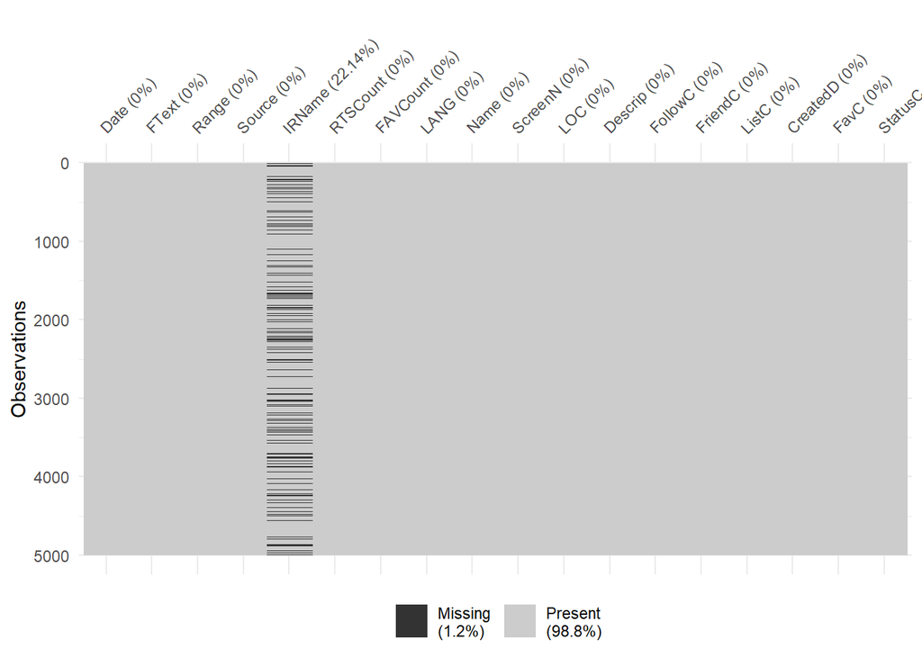

```r
vis_miss(ExDT1, warn_large_data = FALSE)
```

# MUNGE 11

- Twitter Tweet Text: Clean Full Text == ‘FText’ Variable in ExDT1 using Corpus/TM MAP()

```r
text_corpus <- Corpus(VectorSource(ExDT1$FText))
text_corpus <- tm_map(text_corpus, tolower)
text_corpus <- tm_map(text_corpus, removeWords, stopwords("english"))
text_corpus <- tm_map(text_corpus, removePunctuation)
text_corpus <- tm_map(text_corpus, removeWords, c("since", "for", "this",
                                                  "like", "that", "our",
                                                  "will", "s", "ve", "'", "amp",
                                                  "just", "will", "can", "one",
                                                  "since", "like", "look", "also",
                                                  "draseemmalhotra", "per", "it's", "united"))
text_df <- data.frame(text_clean = get("content", text_corpus), stringsAsFactors = FALSE)
```

# MUNGE 12

- Clean ‘Source’ Variable in ExDT1 using Gsub()

```r
ExDT1$Source <- gsub("\\$", "", ExDT1$Source)
ExDT1$Source <- gsub("@\\w+", "", ExDT1$Source)
ExDT1$Source <- gsub("[[:punct:]]","", ExDT1$Source)
ExDT1$Source <- gsub("http\\w+", "", ExDT1$Source)
ExDT1$Source <- gsub("[ |\t]{2,}", "", ExDT1$Source)
ExDT1$Source <- gsub("^ ", "", ExDT1$Source)
ExDT1$Source <- gsub(" $", "", ExDT1$Source)
ExDT1$Source <- gsub("RT","", ExDT1$Source)
ExDT1$Source <- gsub("href", "", ExDT1$Source)
ExDT1$Source <- gsub("([0-9])","", ExDT1$Source)
ExDT1$Source <- gsub("a","", ExDT1$Source)
ExDT1$Source <- gsub("relnofollowTwitter","", ExDT1$Source)
ExDT1$Source <- gsub("for","", ExDT1$Source)
ExDT1$Source <- gsub("App","", ExDT1$Source)
ExDT1$Source <- gsub(" ","", ExDT1$Source)
ExDT1$Source <- gsub("relnofollowTweetDeck","Web", ExDT1$Source)
ExDT1$Source <- gsub("Mc","Other", ExDT1$Source)
ExDT1$Source <- gsub("MediStudio","Other", ExDT1$Source)
ExDT1$Source <- gsub("relnofollowBuffer","Other", ExDT1$Source)
ExDT1$Source <- gsub("relnofollowContentStudioio","Other", ExDT1$Source)
ExDT1$Source <- gsub("relnofollowdlvrit","Other", ExDT1$Source)
ExDT1$Source <- gsub("relnofollowEchobox","Other", ExDT1$Source)
ExDT1$Source <- gsub("relnofollowFenix","Other", ExDT1$Source)
ExDT1$Source <- gsub("relnofollowFenixiOS","Other", ExDT1$Source)
ExDT1$Source <- gsub("relnofollowHootsuiteInc","Other", ExDT1$Source)
ExDT1$Source <- gsub("relnofollowIFTTT","Other", ExDT1$Source)
ExDT1$Source <- gsub("relnofollowlnkdtppstging","Other", ExDT1$Source)
ExDT1$Source <- gsub("relnofollowModernGhn","Other", ExDT1$Source)
ExDT1$Source <- gsub("relnofollowPeriscope","Other", ExDT1$Source)
ExDT1$Source <- gsub("relnofollowRSSGround","Other", ExDT1$Source)
ExDT1$Source <- gsub("relnofollowSproutSocil","Other", ExDT1$Source)
ExDT1$Source <- gsub("relnofollowTheTweetedTimes","Other", ExDT1$Source)
ExDT1$Source <- gsub("relnofollowTweetbotiUFS","Other", ExDT1$Source)
ExDT1$Source <- gsub("relnofollowTweetbotMc","Other", ExDT1$Source)
ExDT1$Source <- gsub("relnofollowWhosoeverWill","Other", ExDT1$Source)
ExDT1$Source <- gsub("relnofollowWordPresscom","Other", ExDT1$Source)
ExDT1$Source <- gsub("relnofollowZpiercom","Other", ExDT1$Source)
ExDT1$Source <- gsub("rificiOS","Other", ExDT1$Source)
ExDT1$Source <- gsub("rificMc","Other", ExDT1$Source)
ExDT1$Source <- gsub("OtheriOS","Other", ExDT1$Source)
ExDT1$Source <- gsub("relnofollowLinkedIn","Other", ExDT1$Source)
ExDT1$Source <- gsub("relnofollowTweetbotOther","Other", ExDT1$Source)
ExDT1$Source <- gsub("rificOther","Other", ExDT1$Source)
ExDT1$Source <- gsub("iPd","IPad", ExDT1$Source)
ExDT1$Source <- gsub("iPhone","IPhone", ExDT1$Source)
```

# MUNGE 13

- Twitter Location: Clean Full Text == ‘LOC’ Variable in ExDT1 using Corpus/TM MAP()

```r
text_corpus1 <- Corpus(VectorSource(ExDT1$LOC))
text_corpus1 <- tm_map(text_corpus1, tolower)
text_corpus1 <- tm_map(text_corpus1, removeWords, stopwords("english"))
text_corpus1 <- tm_map(text_corpus1, removePunctuation)
text_corpus1 <- tm_map(text_corpus1, stripWhitespace)
text_corpus1 <- tm_map(text_corpus1, removeWords, c("new", "county", "orange",
                                                  "city", "free", "state",
                                                  "cruz", "san", "head", "rent",
                                                  "stalkers", "wirral", "leeds"))
text_df1 <- data.frame(text_clean1 = get("content", text_corpus1), stringsAsFactors = FALSE)
```

# MUNGE 14

- Bind Textual columns to DataFrame. Rename Columns. Delete uneeded columns.
- Sort columns for Final DataSet and write as .csv

```r
ExDT1 <- cbind(ExDT1, text_df, text_df1)
colnames(ExDT1)[19] = "FText1"
colnames(ExDT1)[20] = "LOC1"
ExDTvFIN <- ExDT1[,-c(2, 5, 8, 9, 10, 11, 16, 21, 22)]
ExDtvFIN1 <- ExDTvFIN[,c(1, 13, 12, 3, 2, 4, 5, 7, 8, 10, 11, 9, 6)]
write.csv(ExDtvFIN1, "ExDT_Final_Dataset.csv")
```

# EXPLORATORY/DESCRIPTIVE ANALYSIS

# OBS 1 - HISTOGRAM

- OBSERVATION(1): Date Data is Concentrated between 12th to 15th of NOV22

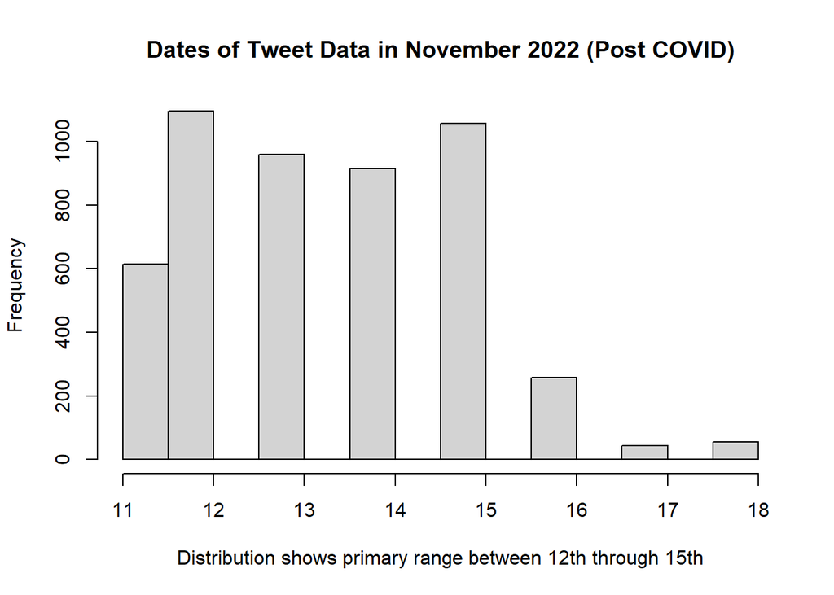

```r
hist(ExDT1$Date, main = "Dates of Tweet Data in November 2022 (Post COVID)",
     xlab = "Distribution shows primary range between 12th through 15th",
     border = "black")
```

# OBS 2 - SCATTERGRAM - OBSERVATION(2): Scatter plot shows Tweet size concentration <400 characters

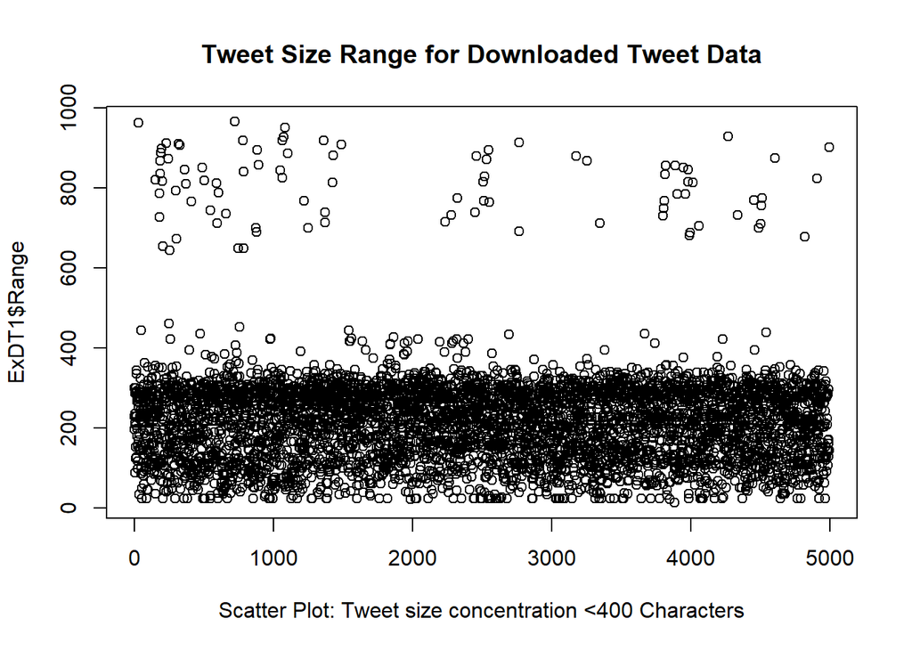

```r
scatter.smooth(ExDT1$Range, main = "Tweet Size Range for Downloaded Tweet Data",
     xlab = "Scatter Plot: Tweet size concentration <400 Characters")
```

# OBS 3 - GGPLOT - OBSERVATION(3): Bar Plot - Shows WEB Applications Exceed - IPhone or Android Usage. # OBS 4 - GGPLOT - OBSERVATION(4): IPhone leads Android usage, but phone usage - exceeds WEB Applications.

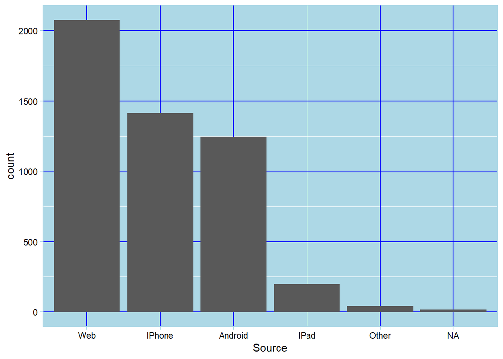

```r
ExDT2 <- ExDT1
ExDT2$Source <- factor(ExDT2$Source,
                       levels = c("Web", "IPhone", "Android", "IPad", "Other"))
ggplot(ExDT2) +
    geom_bar(aes(x = Source)) +
  theme(panel.grid.major  = element_line(color = "blue"),
        panel.background = element_rect(fill = "lightblue"),
        panel.border = element_rect(color = "lightblue", fill = NA),
        axis.line = element_line(color = "lightblue"),
        axis.ticks = element_line(color = "lightblue"),
        axis.text = element_text(color = "black"))
```

WORD/Text CLOUDS ANALYSIS

# OBS 5 - CORPUS

- OBSERVATION(5): Table: TOP 50 Twitter “Excess Deaths”
- Associated Words used in Tweets # OBS 6 - CORPUS
- OBSERVATION(6): Tweets - TOP 50 Show strong opinion correlation
- to COVID Vaccine Usage

```r
FTWord <- (text_df$text_clean)
FTWord <- VectorSource(FTWord)
FTWord <- Corpus(FTWord)
FTWordT <- TermDocumentMatrix(FTWord)
FTWordM <- as.matrix(FTWordT)
FTWordV <- sort(rowSums(FTWordM),decreasing=TRUE)
FTWordD <- data.frame(word = names(FTWordV),freq = FTWordV)
head(FTWordD, 50)
```

```
##                  word freq
## deaths         deaths 5663
## excess         excess 5035
## covid           covid 1662
## people         people  665
## now               now  615
## data             data  564
## vaccine       vaccine  499
## death           death  410
## ’                   ’  393
## many             many  300
## mortality   mortality  299
## countries   countries  283
## 2020             2020  278
## higher         higher  276
## cause           cause  273
## pandemic     pandemic  270
## vaccines     vaccines  269
## year             year  245
## 2022             2022  241
## week             week  224
## know             know  220
## due               due  211
## 2021             2021  210
## see               see  206
## age               age  206
## still           still  204
## caused         caused  202
## dying           dying  201
## increase     increase  192
## even             even  186
## vax               vax  184
## sweden         sweden  184
## world           world  181
## years           years  180
## think           think  179
## europe         europe  177
## among           among  174
## every           every  167
## heart           heart  166
## health         health  165
## related       related  163
## vaccinated vaccinated  162
## rates           rates  158
## rate             rate  158
## average       average  158
## non               non  155
## time             time  153
## going           going  152
## jab               jab  151
## group           group  151
```

# OBS 7 - BARPLOT

- OBSERVATION(7): BarPlot - TOP 15 Twitter “Excess Deaths” Word Counts # OBS 8
- OBSERVATION(8): Tweets - TOP 15 Show strong opinion correlation
- to COVID Vaccine Usage

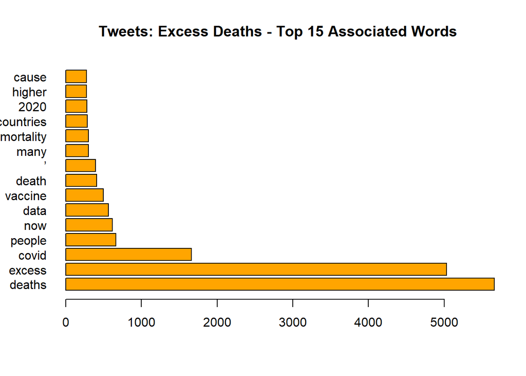

```r
barplot(FTWordV [1:15], main = "Tweets: Excess Deaths - Top 15 Associated Words",
        col = "orange", horiz = TRUE, las = 1)
```

# OBS 9 - WORDCLOUD - OBSERVATION(9): Tweets “Excess Deaths” Word/Text Cloud shows strong - opinion correlation to COVID Vaccines

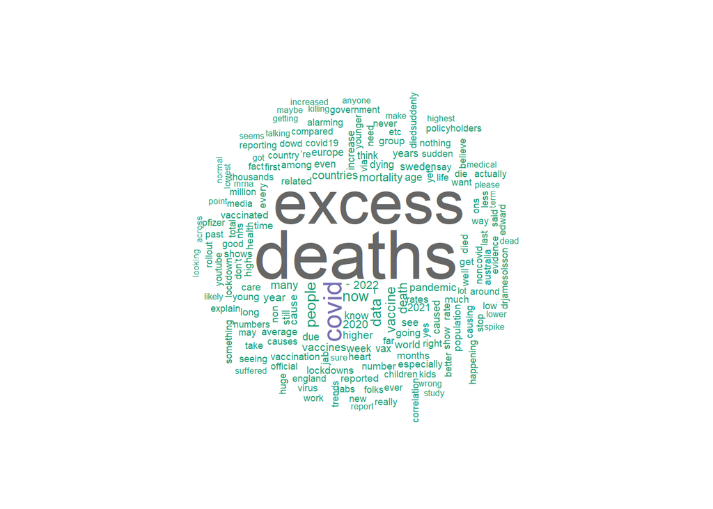

```r
wordcloud(words = FTWordD$word, freq = FTWordD$freq, min.freq = 1,
          max.words=175,random.order=FALSE, rot.per=0.35,
          colors=brewer.pal(8, "Dark2"))
```

# OBS 9a - BIGRAM - Two word combinations of high frequency text usage values

```r
BiGram1 <- ExDT1 %>% unnest_tokens(input = FText1, output = bigram,
                                        token = 'ngrams', n = 2) %>%
  filter(! is.na(bigram))
BiGram1 %>% select(bigram) %>% head(100)
```

```
##                                    bigram
## 1                              dame jenny
## 2                           jenny harries
## 3                         harries blaming
## 4                          blaming summer
## 5                        summer heatwaves
## 6                        heatwaves nearly
## 7                             nearly 3000
## 8                             3000 excess
## 9                           excess deaths
## 10                         deaths pinning
## 11                        pinning climate
## 12                         climate change
## 13                          change deaths
## 14                            deaths part
```

[output cut: 86 more lines]